# Binomial Regression

2022-03-30

## Binomial Regression Model

For when response variable is binomially distributed (probabilities of k successes on n trials.)

for binomial response we need 2 sets of info about the response

y: successes n: number of trials

OR n-y: number of failures

## Example: Challenger Disaster

This is a dataset examining the failure of the O-rings (important component of a space shuttle) under certain conditions

```r
library(tidyverse)
library(faraway)
```

### Linking function in Binomial Regression

The link function is how the predictors are related to the response variable.

In binomial regression, the three common link functions are *Logit*, *Probit* and *Complimentary Log-Log*

They can be used in the GLM model to define how the response fits the predictor.

#### Logit link model

```r
logitmod<-glm(cbind(damage,6-damage)~temp, family=binomial(), data=orings)
summary(logitmod)
```

```
##
## Call:
## glm(formula = cbind(damage, 6 - damage) ~ temp, family = binomial(),
##     data = orings)
##
## Deviance Residuals:
##     Min       1Q   Median       3Q      Max
## -0.9529  -0.7345  -0.4393  -0.2079   1.9565
##
## Coefficients:
##             Estimate Std. Error z value Pr(>|z|)
## (Intercept) 11.66299    3.29626   3.538 0.000403 ***
## temp        -0.21623    0.05318  -4.066 4.78e-05 ***
## ---
## Signif. codes:  0 '***' 0.001 '**' 0.01 '*' 0.05 '.' 0.1 ' ' 1
##
## (Dispersion parameter for binomial family taken to be 1)
##
##     Null deviance: 38.898  on 22  degrees of freedom
## Residual deviance: 16.912  on 21  degrees of freedom
## AIC: 33.675
##
## Number of Fisher Scoring iterations: 6
```

#### Probit link model

```r
probitmod<-glm(cbind(damage,6-damage)~temp, family=binomial(link=probit),orings)
summary(probitmod)
```

```
##
## Call:
## glm(formula = cbind(damage, 6 - damage) ~ temp, family = binomial(link = probit),
##     data = orings)
##
## Deviance Residuals:
##     Min       1Q   Median       3Q      Max
## -1.0134  -0.7761  -0.4467  -0.1581   1.9983
##
## Coefficients:
##             Estimate Std. Error z value Pr(>|z|)
## (Intercept)  5.59145    1.71055   3.269  0.00108 **
## temp        -0.10580    0.02656  -3.984 6.79e-05 ***
## ---
## Signif. codes:  0 '***' 0.001 '**' 0.01 '*' 0.05 '.' 0.1 ' ' 1
##
## (Dispersion parameter for binomial family taken to be 1)
##
##     Null deviance: 38.898  on 22  degrees of freedom
## Residual deviance: 18.131  on 21  degrees of freedom
## AIC: 34.893
##
## Number of Fisher Scoring iterations: 6
```

Note how the difference in the link functions changes the dynamics of the fit to the data

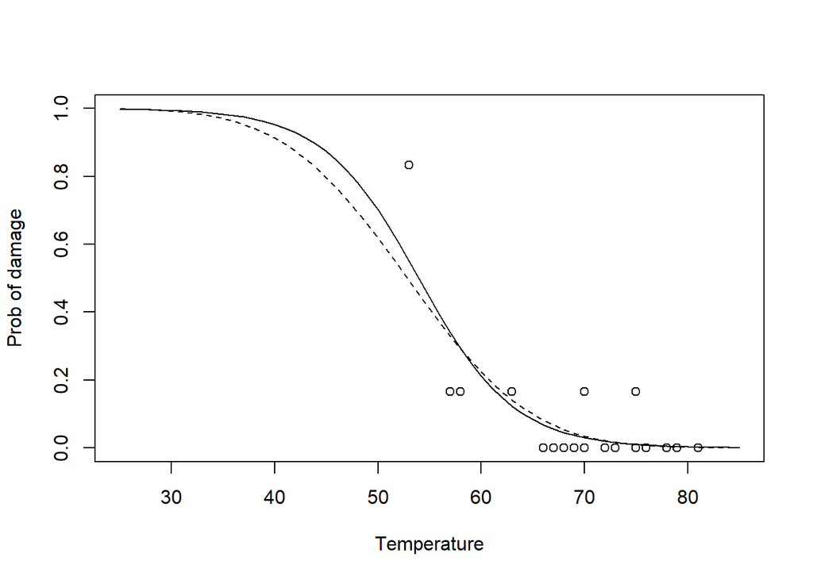

```r
plot (damage/6 ~ temp, orings, xlim=c(25,85),
ylim=c(0,1),
 xlab="Temperature", ylab="Prob of damage")
x <- seq(25,85,1)
lines(x,ilogit(11.6630−0.2162*x))
lines(x, pnorm(5.5915-0.1058*x), lty=2)
```

## Inference

Much like Poisson or Logistic regression. Models are compared to a *saturated model* (i.e. a perfect fit to the data) as opposed to a null model. This changes the way we interpret our p-values

```r
pchisq(deviance(logitmod), df.residual(logitmod),lower=FALSE)
```

```
## [1] 0.7164099
```

recall:

H_0: our model (less complex)

H_A: saturated model (more complex)

since the P-value is HIGH, we say that it fits the data well

### Confidence Intervals

Another method of interpreting our model. If the confidence interval includes zero, then you could reject the model and build something else

```r
library(MASS)
confint(logitmod)
```

```
##                 2.5 %    97.5 %
## (Intercept)  5.575195 18.737598
## temp        -0.332657 -0.120179
```